# Logiciel de gestion de version

- Il facilite le travail collaboratif
- Stock l'historique des modifications
- On peut trvailler sur plusieurs versions de prjets au meme temps
- Possibilité de revenir en arriere
- Permet de travailler sur le meme fichier par plusieurs personnes au meme temps

# Exemple de logiciel

- CVS
- SVN
- GIT (le plus utilisé)
- BAZAAR
- MERCURIAL
- ...

# Pourquoi GIT est le meilleur ?

- Il est crée par LINUS TORVALDS (createur de LINUX)
- les developpeurs possedent tous la meme version avec tout l'historique (en local)
- Disponibilités des depots GIT
- GIT utilise peu de memoire par rapport aux autres VCS

# Installation de GIT

- https://gitforwindows.org/
- Une version en ligne de commande (GIT bash), une version GUI (graphique)
- De preference de commancer par ligne de commande

# GitHub

- https://github.com/account/unverified-email
- racheté par microsoft
- reseau social des developpeurs
- permet de collaborer avec d'autres developpeurs
- on peut creer des projets privés ou publics
- c'est un depot parmis d'autres (GitLab, ...)

# Creation d'un projet Git en local

## Git init

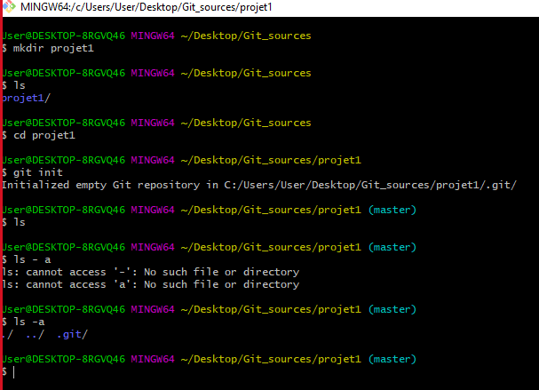

## Git status

- la branche principale s'appelle "master"

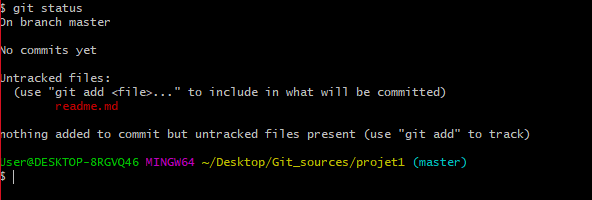

## Git add

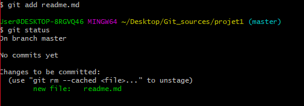

## Git commit

- pour valider les midifications en local

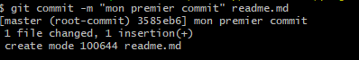

## Git log

- pour voire l'historique

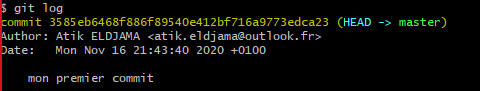

## Git diff

- pour voire les midifications

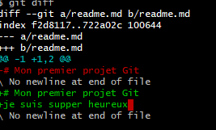

# Creation d'un projet sur GitHub

-creer un repository sur GitHub (pas projet)

## Git clone

-pour recuperer le projet depuis un depot (github) distant vers le local

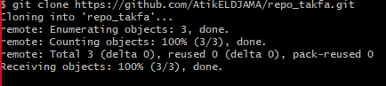